# Introduction to Linear Models

Steve Elston

10/23/2023

# Welcome to the Second Half of CSCI E-83!

Plan going forward:

- Week 8, Oct 24: Introduction to Linear Models
- Week 9, Oct 31: Linear Models Part 2 - Categorical data and nonlinear response models
- Week 10, Nov 7: Linear Models Part 3 - Regularization and sparse models
- Week 11, Nov14: Time Series Models
- Nov 18: Project proposal due
- Week12, Nov 23: Bayes MCMC methods
- Week 13, Nov 28: Hierarchical Bayesian models
- Week 14, Dec 5: - More on time series? - No assignment
- Dec 21: Submit Graduate Independent Projects

Let me know if you have suggestions to update this schedule

# Review

Bayesian analysis is a contrast to frequentist methods

# Introduction - Why linear models?

Linear models are widely used in statistics and machine learning

- Understandable and interpretable
- Generalize well, if properly fit
- Highly scalable – computationally efficient
- Can approximate fairly complex functions
  - A basis of understanding complex models
- Many non-linear models are at locally linear at convergence
  - We can learn a lot about the convergence of DL and RL models from linear approximations
- In this lesson we take a **frequentist view** of the linear model
  - Bayesian view is also widely used

# Introduction - Why linear models?

Linear models are **readily interpretable!**

- Human interpretability is of great importance for models used for critical decisions
  - Health care
  - Safe operation of autonomous systems
  - Social justice for applications with human impact
  - etc.
- Model coefficients provide information on response sensitivities to changes in variables
  - Low chance of *unexpected output*
  - Complex and nonlinear model result in poor human intuition about expected response
  - Complex and nonlinear models vulnerable to *unexpected output*

# Why Linear Models

What are the alternatives?

- Linear models are scaleable and interpretable
  - Idea if **goal is inference and exploration**
  - Can **identify data problems** more easily
  - May have lower prediction accuracy on some problems
- AdaBoost algorithms are go-to models for prediction on tabular data
  - Known to give superior predicitons, **but clean data matter more!**
  - Interpretability is nearly impossible
  - Limits inference and exploration opportunities

# What is regression?

In statistics, **regression** refers to a family of model that attempt to predict the value of numeric random variable

- Regression is a common form of a linear model
- Linear regression is a building block of many statistical and ML methods:
  - multivariate regression and principal component
  - Analysis of variance (ANOVA)
  - Polynomial regression
  - Logistic regression for binary classification
  - Poisson regression
  - Many time series models
  - Neural networks (and deep learning)

# Terminology

The confusing division in terminology arises from different communities within statistics and machine learning

| Machine Learning Terminology | Statistical Terminology |
| --- | --- |
| Regression vs classification | Continuous numeric vs categorical response |
| Learning algorithm or model | Model |
| Training | Fitting |
| Trained model | Fitted model |
| Supervised learning | Predictive modeling |

# Terminology

Different communities have created different terminology at different times for the variables in a machine learning models

| Predicted Variable | Variables Used to Predict |
| --- | --- |
| y | x |
| Dependent | Independent |
| Endogenous | Exogenous |
| Response | Predictor |
| Response | Explanatory |
| Label | Feature |
| Regressand | Regressors |
| Outcome | Design |
| Left Hand Side | Right Hand Side |

# Formulating the Linear Model

The general formulation of a linear model can be written:

$$\vec{y} = A \vec{b} +
\vec{\epsilon}$$

- $\vec{y}$ is the vector of $n$ dependent variables or labels we seek to predict
- $A$ is the $n$ x $p$ **model matrix** or **design matrix**
  - Defines the structure of the model
  - $p$ columns are values of the predictor variables or features
  - $n$ rows of training cases
- $\vec{b}$ is the vector of $p$ model coefficients
  - One coefficient for each predictor or feature
  - Model is fit by finding an **optimal** value for each coefficient

# Formulating the Linear Model

The general formulation of a linear model can be written:

$$\vec{y} = A \vec{b} +
\vec{\epsilon}$$

- $\epsilon$ is the vector representing **prediction error**
  - The $n$ **residuals**
  - Is **iid Normally distributed**; $\epsilon \sim \mathcal{N}(0, \sigma^2)$

# Single Predictor Regression

Consider a simple case of regression with a single predictor

- Only two coefficients ($p=2$) defining a straight line

$$\vec{b} =
\begin{bmatrix}
\beta_0\\
\beta_1
\end{bmatrix}$$

- $\beta_0 =$ the **intercept term**
  - Intercept is value of $y$ at $x=0$
- $\beta_1 =$ model **coefficient** for the predictor variable
  - The **slope coefficient**

# Single Predictor Regression

Consider a simple case of regression with a single predictor

- Given a variable predictor value $x_i$, the prediction, $\hat{y}_i$, is:

$$\begin{align}
\hat{y}_i &= \beta_0 + \beta_1 x_i\\
\hat{y}_i &= y - \epsilon_i\\
\epsilon_i &\sim \mathcal{N}(0, \sigma^2)
\end{align}$$

- $\epsilon_i$ is the **0 mean Normally distributed residual**; $\mathtt{E}(\epsilon_i) = 0$

# Example

Let’s start with a simulated data set with one predictor and one response variable

```
##           x         y
## 0  0.000000  1.951736
## 1  0.204082  0.627047
## 2  0.408163  3.025441
## 3  0.612245  1.112869
## 4  0.816327  5.225976
## 5  1.020408 -0.382646
## 6  1.224490  3.969339
## 7  1.428571  2.834755
## 8  1.632653  1.516411
## 9  1.836735  2.958745
```

# Example

Notice the linear trend for these data

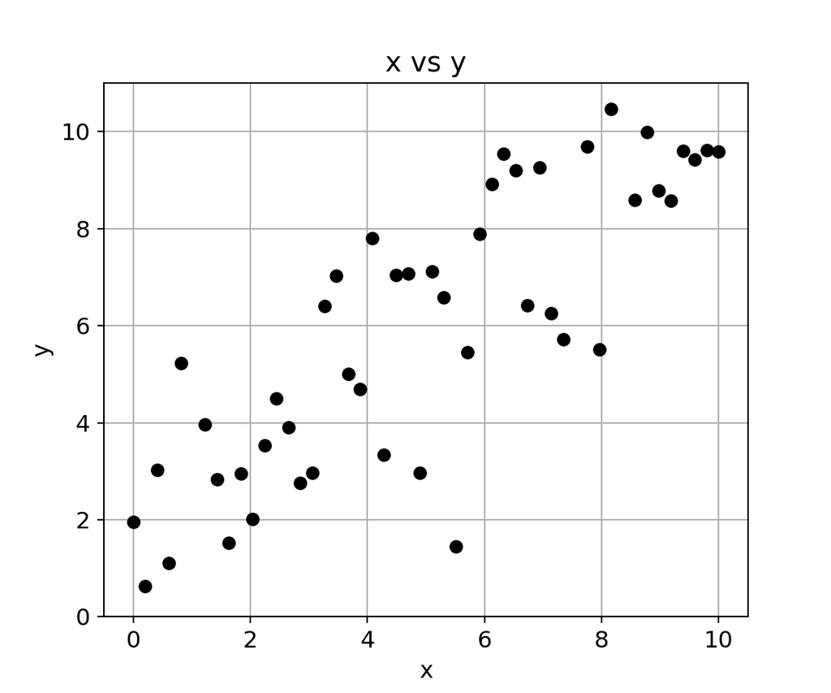

How do we compute a best fit model for this relationship

# The Model Matrix

How do we create the model matrix

- Start with a data table of $n$ samples with $p=2$ columns
  - First column is predictor variable
  - Second column is the response variable

$$\begin{bmatrix}
x_1, y_1\\
x_2, y_2\\
x_3, y_3\\
\vdots, \vdots\\
x_n, y_n
\end{bmatrix}$$

# The Model Matrix

The **model matrix** for this case, including the intercept term is:

$$\begin{bmatrix}
1, x_1\\
1, x_2\\
1, x_3\\
\vdots, \vdots\\
1, x_n
\end{bmatrix}$$

The column of 1’s define the intercept term

# Constructing the Model

For the $n$ data samples and the parameter vector $\vec{b}$ we can construct the entire model:

$$\begin{bmatrix}
y_1\\
y_2\\
y_3\\
\vdots\\
y_n
\end{bmatrix}
=
\begin{bmatrix}
1, x_1\\
1, x_2\\
1, x_3\\
\vdots, \vdots\\
1, x_n
\end{bmatrix}
\begin{bmatrix}
\beta_0\\
\beta_1
\end{bmatrix}
+
\begin{bmatrix}
\epsilon_1\\
\epsilon_2\\
\epsilon_3\\
\vdots\\
\epsilon_n
\end{bmatrix}$$
For a single prediction:

$$y_i = \beta_0 + \beta_1 x_i +
\epsilon_i$$

Or, in matrix notation:

$$\hat{y} = A \vec{b} +
\vec{\epsilon}$$

We are assuming that the **error, $\epsilon$, is only attributable to the dependent variable**, $y$

# Estimating the Model Parameters

How do we find the best value for the coefficients

- Need to minimize an **error metric**
- Find $\vec{b}$ by minimizing the **sum of squared errors** is known as the **least squares** method
- Given training data, minimize the squared error between the prediction, $\hat{y}_i$, and the observed response variable or label, $y_i$:

$$\min_{\vec{b}} \sum_i(y_i - A_{i,.}
\hat{b})^2 = \min_{\vec{b}} \sum_i(y_i - \hat{y_i})^2 = \min_{\vec{b}}
\sum_i \epsilon_i^2$$

$A_{i,.}$ is the ith row of $A$

# Estimating the Model Parameters

We could try a naive solution:

$$\vec{b} = A^{-1}y$$

Where $A^{-1}$ is the **matrix inverse** of $A$

- This *might work*, **BUT**
- Direct matrix inverse algorithm has complexity $O(n^3)$, so inefficient
- There is no guarantee the inverse exists
  - The $p$ features can be colinear

# Estimating the Model Parameters

We can use the **Normal equations**

- Start with the problem:

$$y - A \vec{b} = \vec{\epsilon}
\rightarrow 0$$

- Multiply by $A^T$ and set $\vec{\epsilon} = 0$

$$A^TA \vec{b} = A^T \hat{y}$$

- Taking the inverse of $A^T A$ we arrive at the normal equations

$$\vec{b} = (A^TA)^{-1}A^T
\hat{y}$$

# Estimating the Model Parameters

We can use the **Normal equations**

$$\vec{b} = (A^TA)^{-1}A^T
\hat{y}$$

- $\frac{1}{p} A^TA$ is the **covariance matrix** for the data set
  - Is dimension only $p$ x $p$
  - For single predictor model this is just dimension 2x2
  - Much easier to take inverse
  - But poor scaling for large-scale problems, $p > 1,000$

# Estimating the Model Parameters

What is the relationship between the normal equations, least squares and maximum likelihood?

- First consider how the Normal likelihood can be written in terms of $\vec{b}$ with $n$ feature vectors of observations $\vec{x}_i$ and $n$ labels $y_i$:

$$\mathcal{L}(\vec{b}, \sigma^2) =
\prod_{i=1}^n \frac{1}{(2 \pi \sigma^2)^{1/2}} exp \Big\{ -\frac{1}{2
\sigma^2} \big(y_i - x_i^T \vec{b} \big)^2 \Big\}$$

- The log-likelihood is then:

$$\mathcal{l}(\vec{b}, \sigma^2) =
-\frac{1}{2} \Bigg\{ n\ log(\sigma^2) + \frac{1}{\sigma^2} \sum_{i=1}^n
\big(y_i - x_i^T \vec{b} \big)^2 \Bigg\}$$

- For a fixed $\sigma^2$ one can see that the **log-likelihood is maximized by minimizing the squared error:**

$$SS(\vec{b}) = \sum_{i=1}^n \big(y_i -
x_i^T \vec{b} \big)^2$$

# Estimating the Model Parameters

Minimize sum of square errors to maximize log-likelihood

- Set the first derivative of sum of square errors to zero

$$\frac{\partial\ SS(\vec{b})}{\partial\
\vec{b}} = 2 \sum_{i=1}^n x_i^T \big(y_i - x_i^T \vec{b} \big) =
0$$
Or, in matrix form:

$$A^T (\vec{y} - A \vec{b}) =
0$$

- Solving the above leads to the **normal equations:**

$$\vec{b} = (A^TA)^{-1}A^T
\hat{y}$$

- But still need to compute inverse of covariance matrix, $A^TA$

# Estimating the Model Parameters

Are there more scalable ways to solve the least squares problems?

- Inverting the covariance matrix is a big improvement over a naive approach, it still requires taking a large matrix inverse at scale. $p > 1,000$
- Can we solve the least squares problem in a more computationally efficient way?
- Start with the linear equations for maximum likelihood

$$A^T (\vec{y} - A \vec{b}) =
0$$

- Eliminate $A^T$ from both sides

$$\vec{y} - A \vec{b} = 0$$

- We can find the minimum of this linear system with an efficient solver
  - **Stochastic Gradient Descent (SGD)** and its relatives
  - Quasi-Newton methods like **L-BFGS**

# Estimating the Model Parameters

What is the relationship between the normal equations, least squares and maximum likelihood?

- Solving the least problem is equivalent to solving the maximum likelihood estimation problem
- The normal equations are a maximum likelihood estimator
- Solving the system of linear equations, $\vec{y} - A \vec{b} = 0$, results in a least squares maximum likelihood solution
- The above applies when residuals are Normally distributed

# Example - Specifying the Model

How do we specify the model formula with statsmodels?

- Use the S/R style model formula developed by [Chambers and Hastie; Statistical Models in S (1992)](https://www.taylorfrancis.com/books/e/9780203738535).
- Uses the $\sim$ operator to mean *modeled by**

$$dependent\ variable\sim indepenent\
variables$$

- Example; dependent variable (dv) modeled by two independent variables (var1 and var2):

$$dv \sim var1 + var2$$

- Example; dependent variable (dv) modeled by independent variables (var1) and its square, uses the $I()$ operator to wrap a function:

$$dv \sim var1 + I(var1**2)$$

# Example - Specifying the Model

How do we specify the model formula with statsmodels?

- Example; dependent variable (dv) is modeled by two independent variables (var1 and var2) and the **interaction term** with no intercept term:

$$dv \sim -1 + var1*var2 \longleftrightarrow
dv \sim -1 + var1 + var2 + var1:var2$$

- Example; dependent variable (dv) modeled by independent numeric variable (var1) and a categorical variable (var2):

$$dv \sim var1 + C(var2)$$

# Example - Fitting the Model

Fit the model using statsmodels.formula.api.ols to create a linear model object

```python
## Define the regression model and fit it to the data
ols_model = smf.ols(formula = 'y ~ x', data=sim_data).fit()

## Print the model coefficient
print('Intercept = %4.3f  Slope = %4.3f' % (ols_model._results.params[0], ols_model._results.params[1]))
```

```
## Intercept = 1.611  Slope = 0.882
```

Find the predicted values for each value of $x$:

```python
# Add predicted to pandas dataframe
sim_data['predicted'] = ols_model.predict(sim_data.x)
# View head of data frame
sim_data.head(5)
```

```
##           x         y  predicted
## 0  0.000000  1.951736   1.611189
## 1  0.204082  0.627047   1.791233
## 2  0.408163  3.025441   1.971277
## 3  0.612245  1.112869   2.151321
## 4  0.816327  5.225976   2.331365
```

# Example - Model Checking

Plot the regression line against the original data

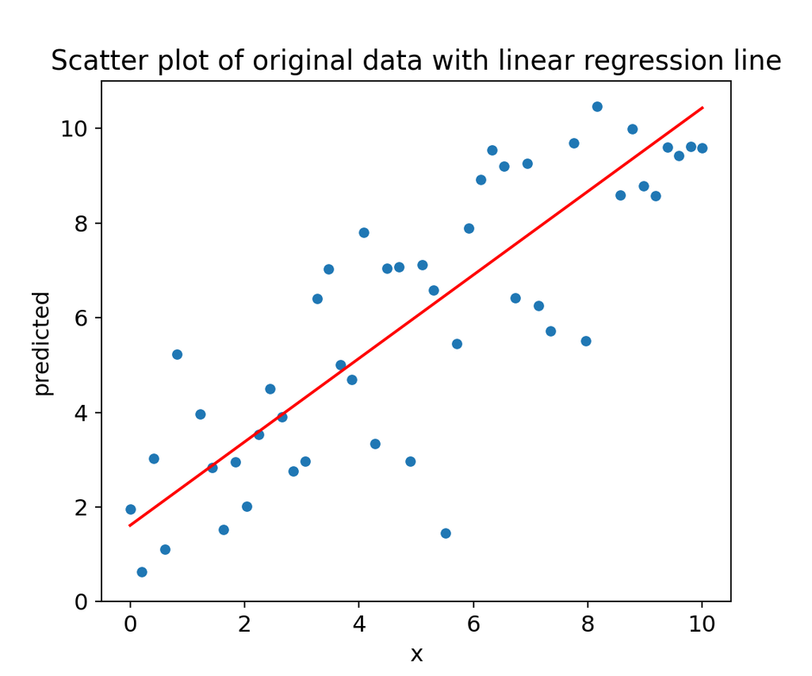

This looks like a good fit, but how good is it really?

# Evaluating Regression Models

Evaluation of regression models focuses on the residuals or errors

$$\vec{\epsilon} = \vec{y} - A\ \vec{b} =
\vec{y} - \hat{y}$$

- Residuals should be Normally distributed with $0$ mean and constant variance

$$\vec{\epsilon} \sim
\mathcal{N}(0,\sigma^2)$$

- The residuals must be **homoskedastic** with respect to the fitted values
  - Homoskedastic residuals have constant variance with predicted values
- Any trend or structure in the residuals indicates a poor model fit
  - In these cases variance is not constant and we say these are **heteroskedastic** residuals
  - Heteroskedastic residuals indicate that model has not incorporated all available information

# Evaluating Regression Models

**Residual plots** is a key diagnostic for any regression model

- Plot residual against the predicted values

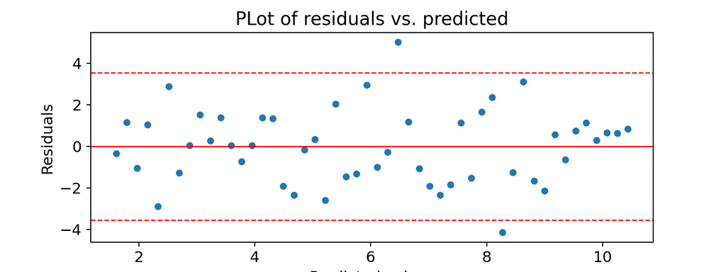

- These residuals look homoskedastic - we are happy!

# Evaluating Regression Models

Graphically test that the residuals are iid Normal

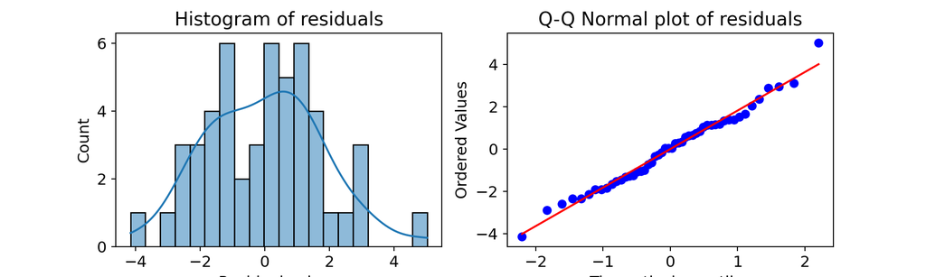

- These plots look promising

# Evaluating Regression Models

We can quantitatively understand model performance by defining these relationships

$$\begin{align}
SST &= sum\ square\ total\ = \Sigma_i(y_i - \bar{Y})^2 \\
SSE &= sum\ square\ explained\ = \Sigma_i{(\hat{y_i} - \bar{Y})^2}\\
SSR &= sum\ square\ residual\ = \Sigma_i{(y_i - \hat{y_i})^2}\\
\end{align}$$

The relationship between these metrics:

$$SST = SSR + SSE$$

Or, we can say that the sum of squares explained by the model is:

$$SSE = SST - SSR$$

# Evaluating Regression Models

Compute the sums of squares for the running example

```python
y_bar = np.mean(sim_data.y)
SST = np.sum(np.square(np.subtract(sim_data.y, y_bar)))
SSR = np.sum(np.square(sim_data.resids))
SSE = np.sum(np.square(np.subtract(sim_data.predicted, y_bar)))
print('SST = {0:6.2f}'.format(SST))
```

```
## SST = 494.61
```

```python
print('SSE = {0:6.2f}'.format(SSE))
```

```
## SSE = 337.53
```

```python
print('SSR = {0:6.2f}'.format(SSR))
```

```
## SSR = 157.08
```

```python
print('SSE + SSR = {0:6.2f}'.format(SSE + SSR))
```

```
## SSE + SSR = 494.61
```

- The model has explained most of the SST

# Evaluating Regression Models

We can compare the sum of square residual to the sum of square total to evaluate how well our model explains the data

$$SST - SSR = SSE$$
We call the ratio $\frac{SSE}{SST}$ $R^2$ or the **coefficient of determination**

$$R^2 = 1 - \frac{SSR}{SST}$$

The $R^2$ for a perfect model would behave as follows:

$$\begin{align}
SSR &\rightarrow 0\\
R^2 &\rightarrow 1
\end{align}$$

A model which does not explain the data at all has:

$$\begin{align}
SSR &\rightarrow SST \\
R^2 &\rightarrow 0
\end{align}$$

# Evaluating Regression Models

As the number of model parameters increases the model will fit the data better

- But, the model will become over-fit as the number of parameters increases
- Must adjust model performance for degrees of freedom - **adjusted** $R^2$

$$\begin{align}
R^2_{adj} &= 1 - \frac{\frac{SSR}{df_{SSR}}}{\frac{SST}{df_{SST}}} =
1 - \frac{var_{residual}}{var_{total}}\\
where\\
df_{SSR} &= SSR\ degrees\ of\ freedom\\
df_{SST} &= SST\ degrees\ of\ freedom
\end{align}$$

This gives $R^2_{adj}$ as:

$$\begin{align}
R^2_{adj} &= 1 - (1 - R^2) \frac{n - 1}{n - k}\\
where\\
n &= number\ of\ data\ samples\\
k &= number\ of\ model\ coefficients
\end{align}$$

# Evaluating Regression Models

As the number of model parameters increases the model will fit the data better

We can expression $R^2_{adj}$:

$$\begin{align}
R^2_{adj} &= 1 - (1 - R^2) \frac{n - 1}{n - k}\\
where\\
n &= number\ of\ data\ samples\\
k &= number\ of\ model\ coefficients
\end{align}$$

Or, we can rewrite $R^2_{adj}$ as:

$$R^2_{adj} = 1.0 -
\frac{SSR}{SST} \frac{n - 1}{n - 1 - k}$$

# Evaluating Regression Models

The summary table for the OLS model provides a number of summary statistics

```python
ols_model.summary()
```

OLS Regression Results

| Dep. Variable: | y | R-squared: | 0.682 |
| --- | --- | --- | --- |
| Model: | OLS | Adj. R-squared: | 0.676 |
| Method: | Least Squares | F-statistic: | 103.1 |
| Date: | Tue, 24 Oct 2023 | Prob (F-statistic): | 1.52e-13 |
| Time: | 12:18:02 | Log-Likelihood: | -99.565 |
| No. Observations: | 50 | AIC: | 203.1 |
| Df Residuals: | 48 | BIC: | 207.0 |
| Df Model: | 1 |  |  |
| Covariance Type: | nonrobust |  |  |

|  | coef | std err | t | P>\|t\| | [0.025 | 0.975] |
| --- | --- | --- | --- | --- | --- | --- |
| Intercept | 1.6112 | 0.504 | 3.196 | 0.002 | 0.598 | 2.625 |
| x | 0.8822 | 0.087 | 10.156 | 0.000 | 0.708 | 1.057 |

| Omnibus: | 0.850 | Durbin-Watson: | 2.312 |
| --- | --- | --- | --- |
| Prob(Omnibus): | 0.654 | Jarque-Bera (JB): | 0.450 |
| Skew: | -0.228 | Prob(JB): | 0.799 |
| Kurtosis: | 3.091 | Cond. No. | 11.7 |

Notes:  
[1] Standard Errors assume that the covariance matrix of the errors is correctly specified.

# Evaluating Regression Models

The summary table for the OLS model provides a number of summary statistics

- **Model coefficients**, with an hypothesis test on the statistical significance
- **F-statistic** and **Prob (F-statistic)** are a measure of the significance of the model against a **null model that does not explain the data**.
- [**Omnibus**](https://en.wikipedia.org/wiki/Omnibus_test), which is a test on the likelihood ratio between the model and a null model
- The $R^2$ and **adjusted $R^2$** indicate the sum of squares explained:
  - The **number of observations**, the $df_{SST}$
  - The **degrees of freedom residuals**, $df_{SSR}$
  - $df_{SST} - df_{SSR} =$ number of model coefficients
- [**Jarque-Bera**](https://en.wikipedia.org/wiki/Jarque%E2%80%93Bera_test) statistic is a test on the skewness and krutosis of the residuals
- The **Condition number** a measure of how well defined the solution is to the system of linear is

# Evaluating Regression Models

We also can evaluate models by error metrics

- The **root mean square error (RMSE)** is a measure of the mean of the squared residuals

$$RMSE = \sqrt{\frac{\Sigma^n_{i-1} (y_i
- \hat{y_i})^2}{n}} = \sqrt{\frac{SSR}{n}}$$

```python
print('RMSE = {0:6.2}'.format(sqrt(np.sum(np.square(sim_data.resids)))/ float(sim_data.shape[0])))
```

```
## RMSE =   0.25
```

- The **median absolute error (MAE)** is a robust measure of mean residuals

$$MAE = med \big[ |y_i - \hat{y_i}|
\big]$$

```python
print('MAE= {0:6.2}'.format(np.median(np.absolute(sim_data.resids))))
```

```
## MAE=    1.3
```

- And many more possibilities…

# Evaluating Regression Models

When evaluating any machine learning model consider **all evaluation methods available**

- No one method is most important all of the time
- **Different methods highlight different problems** with your model
- Don’t forget to check that the **model must make sense** for your application!

# Example - Fitting Centered Model

Fit the model using statsmodels.formula.api.ols with **centered independent variable** to create a linear model object

```python
## Center the independent variable
sim_data.loc[:,'x_centered'] = np.subtract(sim_data.x, np.mean(sim_data.x))
## Define the regression model and fit it to the data
ols_model_centered = smf.ols(formula = 'y ~ x_centered', data=sim_data).fit()

## Print the model coefficient
print('Intercept = %4.3f  Slope = %4.3f' % (ols_model_centered._results.params[0], ols_model_centered._results.params[1]))
```

```
## Intercept = 6.022  Slope = 0.882
```

- We can now interpret this model
  - Intercept is the mean of the dependent variable
  - Slope is the rate of change of the dependent variable for unit change in independent variable
- Interceopt is value of independent variable where independent varaibles all $= 0$
  - May not even be in defined range of independent varaible
  - e.g. How can we interpret a negaive life expectancy

# Example - Fitting center Model

Plot the regression line against the centered independent variable

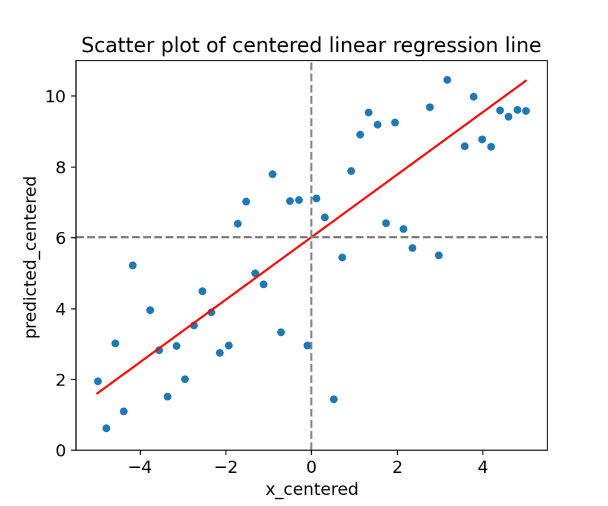

# Extending the Linear Model

We extend the linear model by adding new features or predictor variables

- Higher order terms - e.g. polynomial regression
- Other exogenous variables
- We prefer the simplest model that does a reasonable job
  - The principle of **Occam’s razor**
- Must consider the **bias-variance trade-off**
- **High complexity model** fits the training data well
  - **Low bias**
  - But might not generalize well to new cases - **high variance**
- **Lower complexity model** can **generalize** to new cases
  - **low variance**
  - But does not fit training data as well - **high bias**

# Extending the Linear Model

Building a model matrix for a more complex linear model is easy

- We now have $p + 1$ model coefficients, including intercept term

$$\vec{b} = [\beta_0, \beta_1, \beta_2,
\ldots, \beta_p]$$

- With $p$ features the model matrix is:

$$A =
\begin{bmatrix}
1, x_{1,1}, x_{1,2}, \ldots, x_{1,p}\\
1, x_{2,1}, x_{2,2}, \ldots, x_{2,p}\\
1, x_{3,1}, x_{3,2}, \ldots, x_{3,p}\\
\vdots,\ \vdots,\ \vdots,\ \vdots,\ \vdots\\
1, x_{n,1}, x_{n,2}, \ldots, x_{n,p}
\end{bmatrix}$$

- We still seek the least squares solution
- The covariance matrix is now $p+1$ x $p+1$, including intercept term

# Example of Multi-Feature Linear Model

A new simulated data set

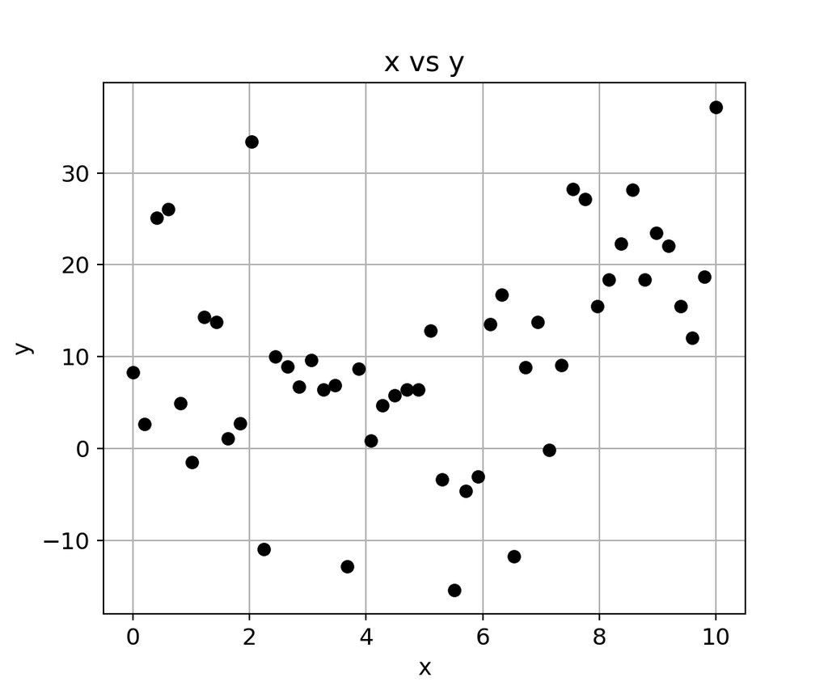

# Example of Multi-Feature Linear Model

First, try a simple straight line model with intercept and slope terms

```
## Intercept = 10.256  Slope = 1.296
```

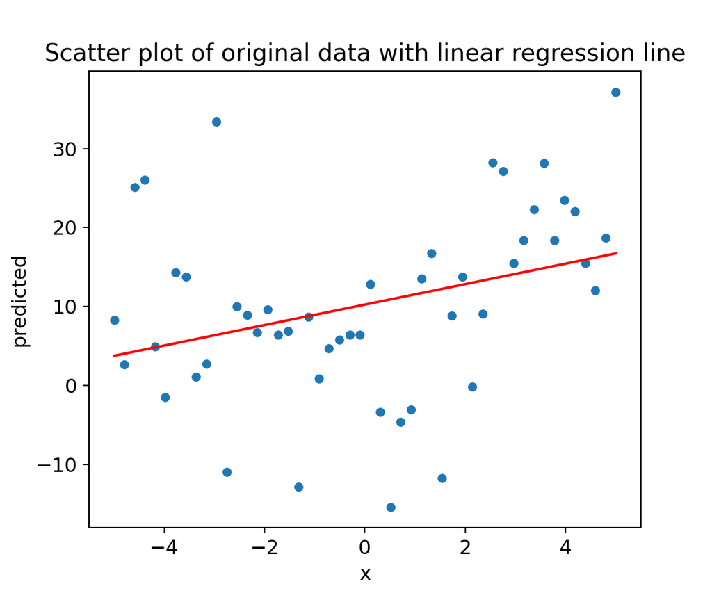

# Example of Multi-Feature Linear Model

What do the residuals look like?

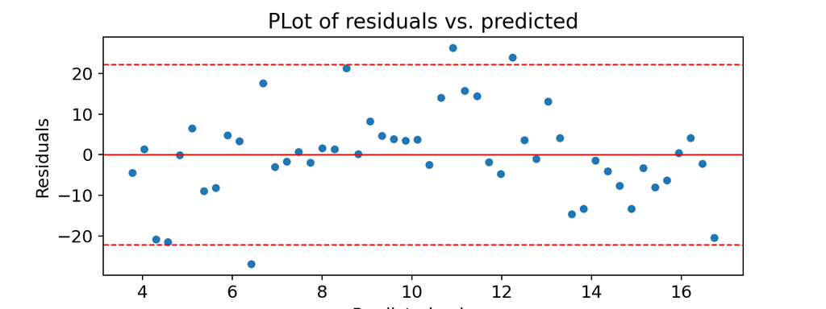

- These residuals look heteroskedastic!

# Example of Multi-Feature Linear Model

Test that the residuals are iid Normal

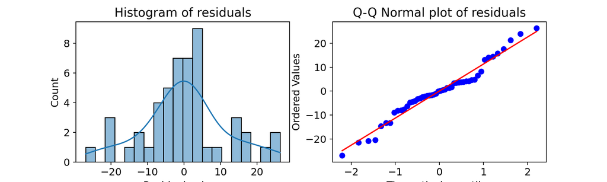

- Do these residuals have Normal distribution?

# Example of Multi-Feature Linear Model

The model summary is:

OLS Regression Results

| Dep. Variable: | y | R-squared: | 0.106 |
| --- | --- | --- | --- |
| Model: | OLS | Adj. R-squared: | 0.087 |
| Method: | Least Squares | F-statistic: | 5.684 |
| Date: | Tue, 24 Oct 2023 | Prob (F-statistic): | 0.0211 |
| Time: | 12:18:06 | Log-Likelihood: | -191.24 |
| No. Observations: | 50 | AIC: | 386.5 |
| Df Residuals: | 48 | BIC: | 390.3 |
| Df Model: | 1 |  |  |
| Covariance Type: | nonrobust |  |  |

|  | coef | std err | t | P>\|t\| | [0.025 | 0.975] |
| --- | --- | --- | --- | --- | --- | --- |
| Intercept | 10.2555 | 1.600 | 6.408 | 0.000 | 7.038 | 13.473 |
| x | 1.2955 | 0.543 | 2.384 | 0.021 | 0.203 | 2.388 |

| Omnibus: | 0.893 | Durbin-Watson: | 1.502 |
| --- | --- | --- | --- |
| Prob(Omnibus): | 0.640 | Jarque-Bera (JB): | 0.269 |
| Skew: | -0.037 | Prob(JB): | 0.874 |
| Kurtosis: | 3.352 | Cond. No. | 2.95 |

Notes:  
[1] Standard Errors assume that the covariance matrix of the errors is correctly specified.

# Example of Multi-Feature Linear Model

Let’s add a second order polynomial term, so the model is now:

$$y = \beta_0 + \beta_1 x + \beta_2
x^2$$

```
## Intercept = 4.051  Partial Slope = 1.296  Second Order Partial slope = 0.715
```

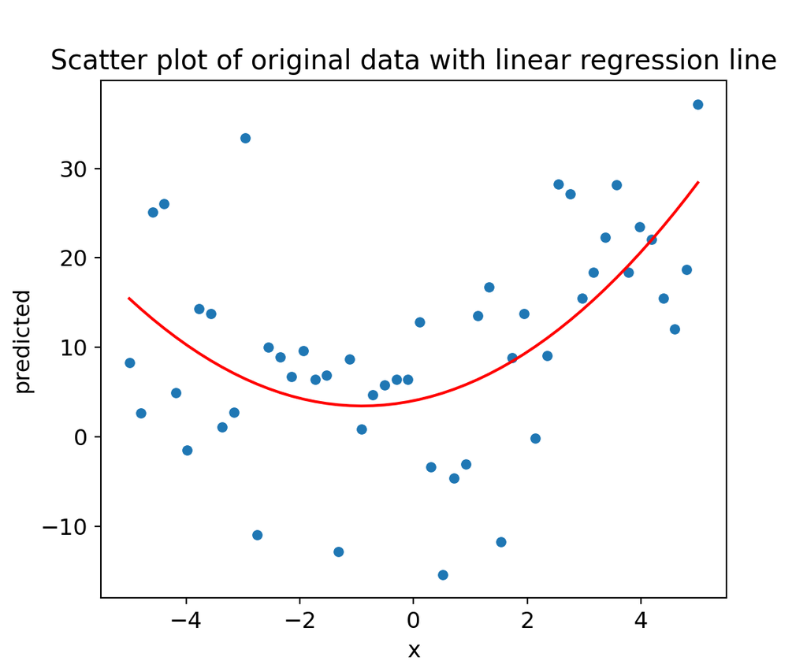

# Example of Multi-Feature Linear Model

What do the residuals look like with the second order term?

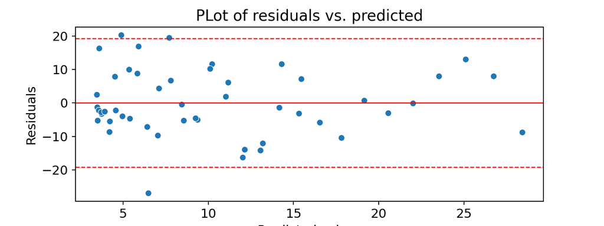

- These residuals are close to homoskedastic!

# Example of Multi-Feature Linear Model

Test that the residuals are iid Normal for the polynomial model

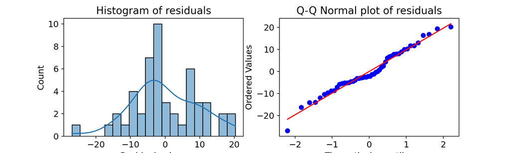

- Do these residuals have close to a Normal distribution?

# Example of Multi-Feature Linear Model

The second order model summary is:

OLS Regression Results

| Dep. Variable: | y | R-squared: | 0.330 |
| --- | --- | --- | --- |
| Model: | OLS | Adj. R-squared: | 0.301 |
| Method: | Least Squares | F-statistic: | 11.55 |
| Date: | Tue, 24 Oct 2023 | Prob (F-statistic): | 8.29e-05 |
| Time: | 12:18:08 | Log-Likelihood: | -184.04 |
| No. Observations: | 50 | AIC: | 374.1 |
| Df Residuals: | 47 | BIC: | 379.8 |
| Df Model: | 2 |  |  |
| Covariance Type: | nonrobust |  |  |

|  | coef | std err | t | P>\|t\| | [0.025 | 0.975] |
| --- | --- | --- | --- | --- | --- | --- |
| Intercept | 4.0507 | 2.101 | 1.928 | 0.060 | -0.177 | 8.278 |
| x | 1.2955 | 0.476 | 2.725 | 0.009 | 0.339 | 2.252 |
| I(x ** 2) | 0.7154 | 0.181 | 3.960 | 0.000 | 0.352 | 1.079 |

| Omnibus: | 0.305 | Durbin-Watson: | 1.995 |
| --- | --- | --- | --- |
| Prob(Omnibus): | 0.859 | Jarque-Bera (JB): | 0.014 |
| Skew: | 0.009 | Prob(JB): | 0.993 |
| Kurtosis: | 3.081 | Cond. No. | 17.5 |

Notes:  
[1] Standard Errors assume that the covariance matrix of the errors is correctly specified.

# Linear Model Assumptions

There are a number of assumptions in linear models that you overlook at your peril!

- The feature or predictor variables should be **independent** of one another
  - This is rarely true in practice
  - **Multi-colinearity** between features makes the model **under-determined**
- We assume that numeric features or predictors have zero mean and about the same scale
  - We do not want to bias the estimation of regression coefficients with predictors that do not have a 0 mean
  - We do not want to have predictors with a large numeric range dominate training
  - Example: income is in the range of 10s or 100s of thousands and age is in the range of 10s, but apriori income is no more important than age as a predictor
- Values of each predictor or feature should be iid
  - If variance changes with sample, the optimal value of the coefficient could not be constant
  - If there **serial correlation** in the predictor values, the iid assumption is violated - but can account for this such as in time series models

# Dealing With Outliers

Outliers are a persistent problem with statistical and machine learning models

- What are outliers?
  - Errors or noisy measurements
  - Result of improper stratification
- But, may be of interest
  - Depending on the application, outliers can be the **most interesting values**!!
  - May need to explicitly model
  - Example: Fraud detection
  - Example: Scientific discovery
- Outliers can be hard to detect
  - Difficult in high-dimensions
  - Often find by influence on model

# Dealing With Outliers

Example: Add a single outlier regression data set

```
## Intercept = 5.098  Partial Slope = 0.365
```

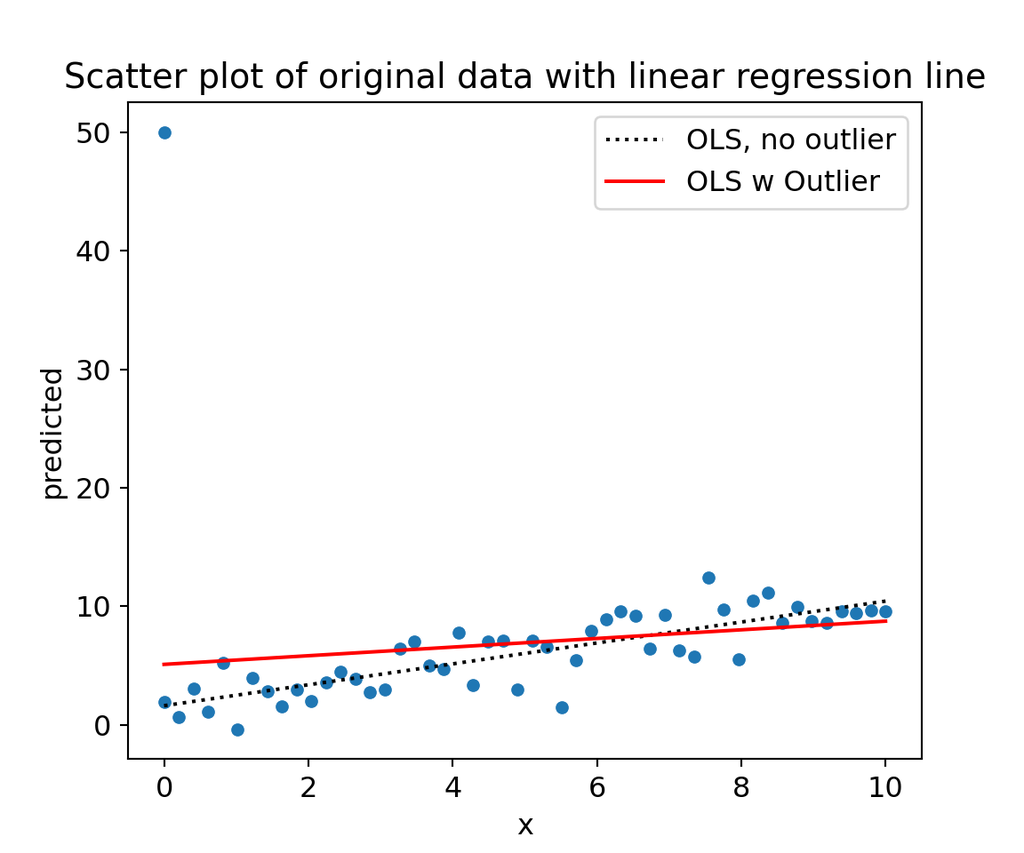

This outlier has **high leverage** and changes the slope significantly

# Dealing With Outliers

**Cook’s distance**, $D_i$, measures the influence of an outlier on a model

- Cook’s distance for the ith data point is the degree of freedom adjusted average squared error against a model without this value

$$D_i = \frac{\Sigma_{j=1}^n (\hat{Y}_j -
\hat{Y}_{j(i)})^2}{n (p+1)\hat{\sigma^2}}$$
where,
$\hat{Y}_{j} =$ the jth prediction computed with all observations
$\hat{Y}_{j(i)} =$ the jth prediction computed without the ith observation
$p =$ number of parameters
$n =$ number of data points

- Cook’s distance is computed using a **leave-one-out resampling algorithm!**

# Dealing With Outliers

Plot Cook’s distance as **leverage** vs. the residual size

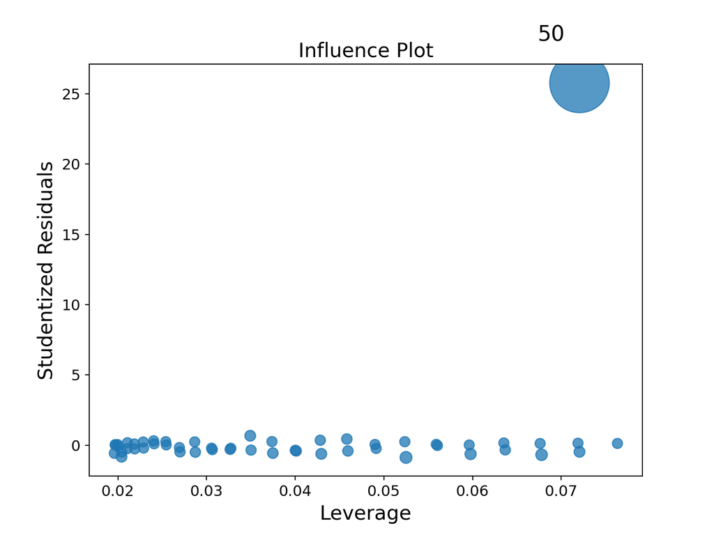

```python
_=influence_plot(ols_model_ol)
```

- Outlying points shown at edges of plot
  - Not all outliers have high leverage
  - Can detect outliers in moderate dimensions

# Dealing With Outliers

Why are linear models sensitive to outliers

- Ordinary linear regression uses **squared error loss** function
  - Optimal if the errors are iid Normal
  - Is an **unbiased estimator**
- In 1-dimension median is robust to outliers
  - But far from an optimal estimator
  - High bias
  - Hard to implement beyond 1-dimension
- We can study the response of estimators to outliers using an **influence function**

# Dealing With Outliers

Compare the influence functions of the mean and median estimators

- Mean estimator has linear influence function
  - Influence of outliers is **unbounded**
  - Derivative of the influence function is constant
- Influence function of median estimator is discontinuous
  - Influence of any observation is constant
  - Derivative of influence function is not defined

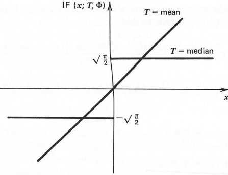

Influence functions for mean and median

*Figure from Hampel, el.al., Robust Statistics, 1986*

# Dealing With Outliers

Could we simply edit out the outliers?

- But what fraction of the data are outliers?
- Know as the **alpha trimmed mean** algorithm
  - Order the values and remove $\alpha / 2$ highest and lowest
  - But, alpha trimming is a bit arbitrary
  - Is a biased estimator, with bias increasing with $\alpha$
  - $\alpha = 0.5$ is the median
- Alpha trimming hard to implement in higher dimensions

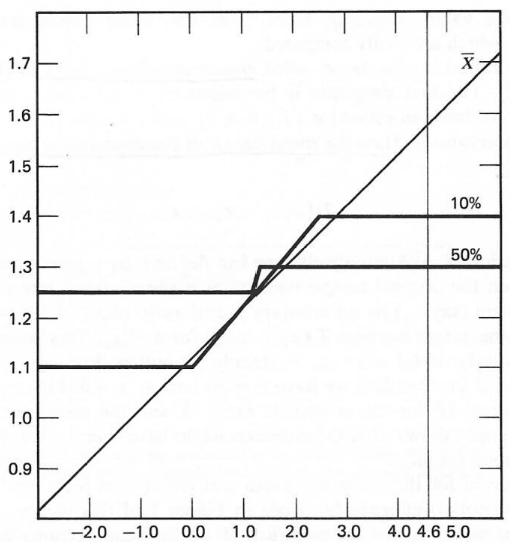

Influence functions for alpha trimmed mean

*Figure from Hampel, el.al., Robust Statistics, 1986*

# Dealing With Outliers

Are there better estimators when outliers are present

- Yes, but must accept some bias
- Idea; estimator can be unbiased near the expected value, but limit influence of outliers
  - Trade-off between high robustness and low bias
- Many ideas have been tried
  - A major research focus in the 1970s and 1980s
  - **Huber estimator**
  - Family of **M-estimators**

# Dealing With Outliers

What are the properties of the Huber estimator?

- Influence function is linear near the mean but constant away from the mean
  - **hinge point** is at $\pm t * MAD$, where $MAD =$ **median absolute deviation**
  - Robustness and bias increases as $t$ decreases
- Huber estimator is low bias
  - Unbiased for samples near the point estimate
  - Constant influence away from the point estimate

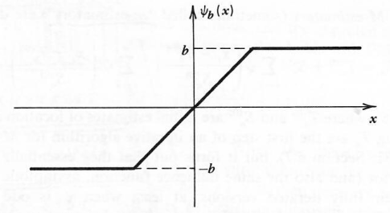

Influence function of the Huber estimator

*Figure from Hampel, el.al., Robust Statistics, 1986*

# Dealing With Outliers

**M-estimators** tapper influence to zero

- Approximately linear influence near point estimate
  - So nearly unbiased near the point estimate
- Influence tappers to 0 for extreme outliers
- An example is **Tukey’s biweight**
  - Only a single parameter for biweight function, $r$
  - Robustness and bias increase with decreasing $r$

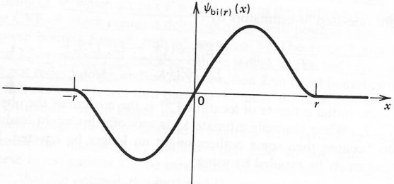

Influence function of the Tukey’s Biweight M-estimator

*Figure from Hampel, el.al., Robust Statistics, 1986*

# Dealing With Outliers

Example: regression with Huber loss function

```python
## Define the robust regression model and fit it to the data
ols_model_huber = smf.rlm(formula ='y~x', data = sim_data_ol).fit()
# Add predicted to pandas data frame
sim_data_ol['predicted_huber'] = ols_model_huber.predict(sim_data_ol.x)
## Display sumamry
ols_model_huber.summary()
```

[output not shown]

# Dealing With Outliers

Example: regression with Huber loss function

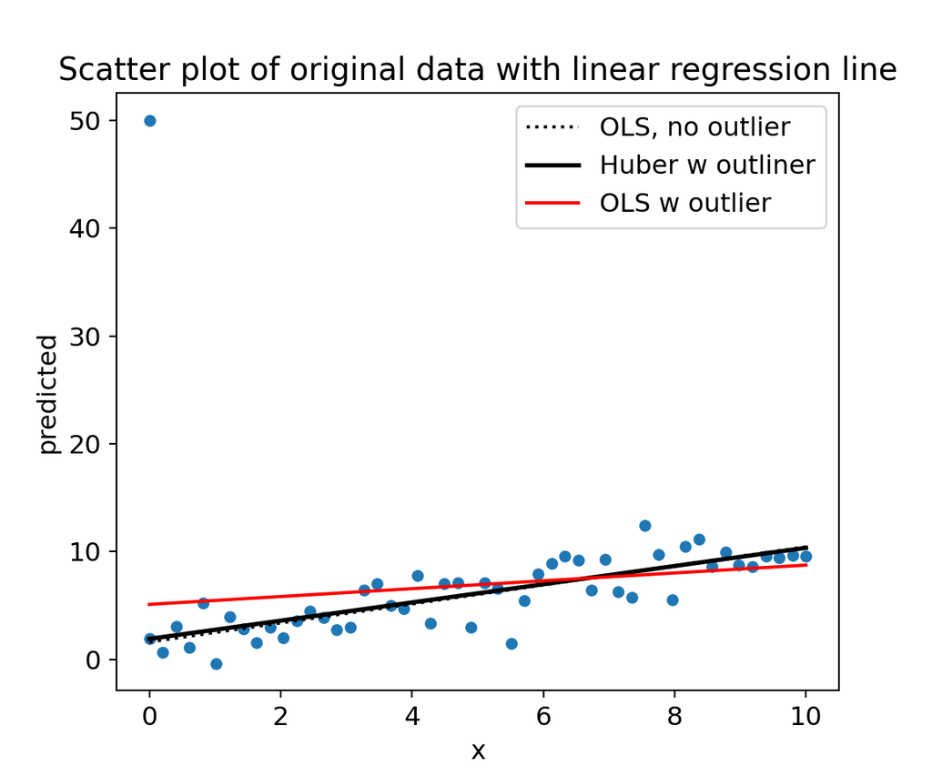

Notice the different slope for the regression with Huber loss

# Summary

Linear models are a flexible and widely used class of models

- Fit model coefficients by **least squares** estimation
- Can use many types of predictor variables
- SGD and L-FBGS algorithms allow massive scaling of linear models
- We prefer the simplest model that does a reasonable job
  - The principle of **Occam’s razor**
- Must consider the **bias-variance trade-off**
- Use robust methods if outliers are present

# Summary

When evaluating any machine learning model consider **all evaluation methods available**

- No one method best all of the time
  - Homoskedastic Normally distributed residuals
  - Reasonable values $R^2$, RMSE, etc
  - Are the model coefficients all significant?
- **Different methods highlight different problems** with your model
- Don’t forget to check that the **model must make sense** for your application!